# Digital Signal and Image Management

### 4. Definizione del modello e fine-tuning

In questa sezione vengono definite delle funzioni in grado di applicare il processo di *fine-tuning* dato in input il modello pre-trainato (ResNet50, VGG16 e MobileNet) e successivamente addestrare tale modello sulle immagini importate precedentemente.  
In particolare, verranno aggiunti i seguenti layer alla rete pre-trainata:

- *Flatten*, in modo da ottenere un array mono-dimensionale
- *Fully Connected* da *512* neuroni e funzione di attivazione *reLu*
- *Fully Connected* da *256* neuroni e funzione di attivazione *reLu*
- *Output*, con dimensione pari al numero delle classi (102 classi) e funzione di attivazione *softmax*

```python
#funzione per la visualizzazione dell'addestramento dei modelli
def plot_history(history, model_name):
  fig = plt.figure(figsize=(18,6))

  fig.add_subplot(1,2,1)
  plt.plot(history.history['accuracy'], marker='.')
  plt.plot(history.history['val_accuracy'], marker='.')
  plt.title('model accuracy')
  plt.ylabel('accuracy')
  plt.xlabel('epoch')
  plt.legend(['train', 'test'], loc='upper left')

  fig.add_subplot(1,2,2)
  plt.plot(history.history['loss'], marker='.')
  plt.plot(history.history['val_loss'], marker='.')
  plt.title('model loss')
  plt.ylabel('loss')
  plt.xlabel('epoch')
  plt.legend(['train', 'test'], loc='upper left')

  fig.suptitle(str(model_name))

  plt.show()
```

```python
def fine_tuning(img_rows, img_cols, color_type, pretrained_model):

  for layer in pretrained_model.layers:
      layer.trainable = False

  model = Sequential()
  model.add(pretrained_model)
  model.add(Flatten())
  model.add(Dense(512, activation = 'relu'))
  model.add(Dense(256, activation = 'relu'))
  model.add(Dense(102, activation = 'softmax'))

  model.summary()

  model.compile(optimizer =  optimizers.Adam(learning_rate = 0.0001), loss='categorical_crossentropy', metrics = ["accuracy"])

  return model
```

```python
def training_model(model_name, img_rows, img_cols, color_type, preproc_function, pretrained_model, data_augment):
  epochs = 100
  train_gen = data_loader(preproc_function, 'train', data_augment)
  test_gen = data_loader(preproc_function, 'test', data_augment)

  model = fine_tuning(img_rows, img_cols, color_type, pretrained_model)

  if os.path.isfile(os.path.join(path_drive+model_name+'.h5')):
    model.load_weights(os.path.join(path_drive+model_name+'.h5'))
    predict = model.predict_generator(test_gen)
    y_true = test_gen.classes
    y_pred = np.argmax(predict, axis=-1)
    f1 = f1_score(y_true, y_pred, average='macro')
    return model, f1

  else:
    callbacks = [ModelCheckpoint(os.path.join(path_drive+model_name+'.h5'), monitor='val_loss', save_best_only=True, verbose=0),
                 EarlyStopping(monitor='val_loss', patience=10, verbose=0)]
    history = model.fit_generator(train_gen, steps_per_epoch=len(train_gen), callbacks=callbacks,
                                  epochs=epochs, validation_data=test_gen, verbose=0)

    plot_history(history, model_name)

    predict = model.predict_generator(test_gen)
    y_true = test_gen.classes
    y_pred = np.argmax(predict, axis=-1)
    f1 = f1_score(y_true, y_pred, average='macro')

  return model, f1
```

### 5. ResNet50

```python
resnet50_model = ResNet50(weights='imagenet', include_top=False,
                          input_shape=(img_rows, img_cols, color_type))
preproc_resnet50 = resnet50.preprocess_input
```

#### 5.1 ResNet50 senza Data Augmentation

```
Found 4600 images belonging to 102 classes.
Found 4544 images belonging to 102 classes.
Model: "sequential_1"
_________________________________________________________________
Layer (type)                 Output Shape              Param #
=================================================================
resnet50 (Model)             (None, 7, 7, 2048)        23587712
_________________________________________________________________
flatten_1 (Flatten)          (None, 100352)            0
_________________________________________________________________
dense_1 (Dense)              (None, 512)               51380736
_________________________________________________________________
dense_2 (Dense)              (None, 256)               131328
_________________________________________________________________
dense_3 (Dense)              (None, 102)               26214
=================================================================
Total params: 75,125,990
Trainable params: 51,538,278
Non-trainable params: 23,587,712
_________________________________________________________________
```

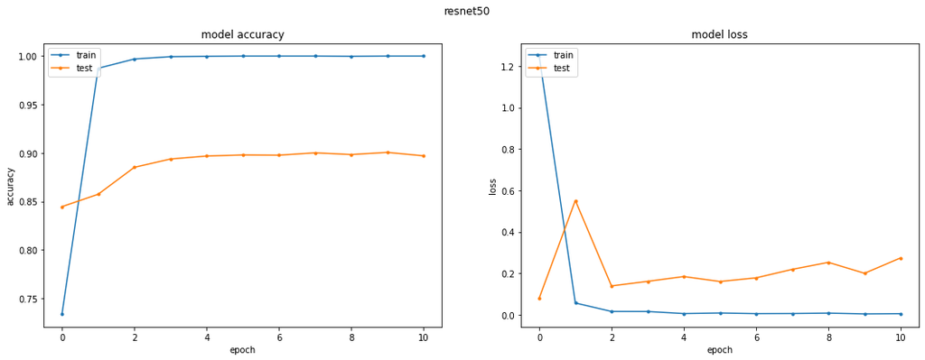

```
CPU times: user 7min 51s, sys: 49.3 s, total: 8min 40s
Wall time: 9min 40s
```

```python
%time resnet50_finetuned = training_model('resnet50',img_rows, img_cols,\
                                          color_type, preproc_function=preproc_resnet50,\
                                          pretrained_model=resnet50_model, data_augment=False)
```

#### 5.2 ResNet50 con Data Augmentation

```
Found 4600 images belonging to 102 classes.
Found 4544 images belonging to 102 classes.
Model: "sequential_2"
_________________________________________________________________
Layer (type)                 Output Shape              Param #
=================================================================
resnet50 (Model)             (None, 7, 7, 2048)        23587712
_________________________________________________________________
flatten_2 (Flatten)          (None, 100352)            0
_________________________________________________________________
dense_4 (Dense)              (None, 512)               51380736
_________________________________________________________________
dense_5 (Dense)              (None, 256)               131328
_________________________________________________________________
dense_6 (Dense)              (None, 102)               26214
=================================================================
Total params: 75,125,990
Trainable params: 51,538,278
Non-trainable params: 23,587,712
_________________________________________________________________
```

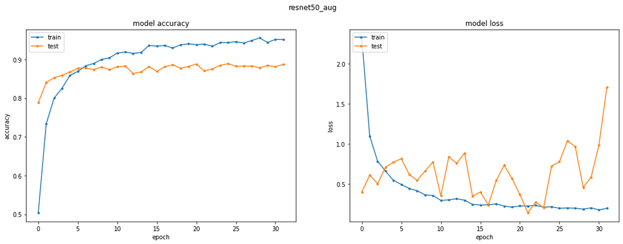

```
CPU times: user 47min 6s, sys: 2min 6s, total: 49min 13s
Wall time: 43min 32s
```

```python
%time resnet50_finetuned_augment = training_model('resnet50_aug',img_rows, img_cols,\
                                                  color_type, preproc_function=preproc_resnet50,\
                                                  pretrained_model=resnet50_model, data_augment=True)
```

### 6. VGG16

```python
vgg16_model = VGG16(weights='imagenet', include_top=False,
                    input_shape=(img_rows, img_cols, color_type))
preproc_vgg16 = vgg16.preprocess_input
```

#### 6.1 VGG16 senza Data Augmentation

```
Found 4600 images belonging to 102 classes.
Found 4544 images belonging to 102 classes.
Model: "sequential_3"
_________________________________________________________________
Layer (type)                 Output Shape              Param #
=================================================================
vgg16 (Model)                (None, 7, 7, 512)         14714688
_________________________________________________________________
flatten_3 (Flatten)          (None, 25088)             0
_________________________________________________________________
dense_7 (Dense)              (None, 512)               12845568
_________________________________________________________________
dense_8 (Dense)              (None, 256)               131328
_________________________________________________________________
dense_9 (Dense)              (None, 102)               26214
=================================================================
Total params: 27,717,798
Trainable params: 13,003,110
Non-trainable params: 14,714,688
_________________________________________________________________
```

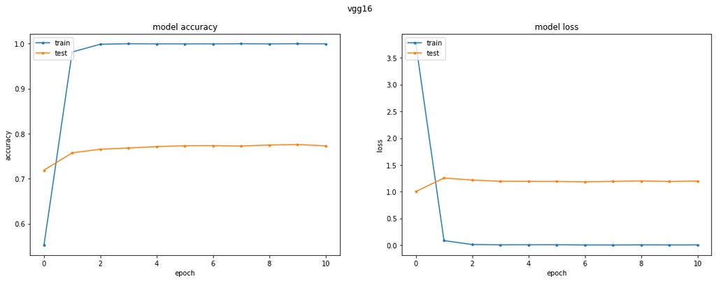

```
CPU times: user 6min 33s, sys: 34.1 s, total: 7min 7s
Wall time: 8min 38s
```

```python
%time vgg16_finetuned = training_model('vgg16',img_rows, img_cols, color_type,\
                                       preproc_function=preproc_vgg16,\
                                       pretrained_model=vgg16_model, data_augment=False)
```

#### 6.2 VGG16 con Data Augmentation

```
Found 4600 images belonging to 102 classes.
Found 4544 images belonging to 102 classes.
Model: "sequential_4"
_________________________________________________________________
Layer (type)                 Output Shape              Param #
=================================================================
vgg16 (Model)                (None, 7, 7, 512)         14714688
_________________________________________________________________
flatten_4 (Flatten)          (None, 25088)             0
_________________________________________________________________
dense_10 (Dense)             (None, 512)               12845568
_________________________________________________________________
dense_11 (Dense)             (None, 256)               131328
_________________________________________________________________
dense_12 (Dense)             (None, 102)               26214
=================================================================
Total params: 27,717,798
Trainable params: 13,003,110
Non-trainable params: 14,714,688
_________________________________________________________________
```

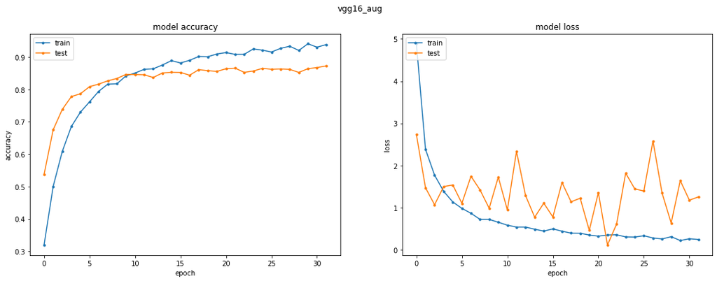

```
CPU times: user 46min 33s, sys: 1min 35s, total: 48min 8s
Wall time: 43min 31s
```

```python
%time vgg16_finetuned_augment = training_model('vgg16_aug', img_rows, img_cols,\
                                               color_type, preproc_function=preproc_vgg16,\
                                               pretrained_model=vgg16_model, data_augment=True)
```

### 7. MobileNet

```python
mobilenet_model = MobileNet(weights='imagenet', include_top=False,
                        input_shape=(img_rows, img_cols, color_type))
preproc_mobilenet = mobilenet.preprocess_input
```

#### 7.1 MobileNet senza Data Augmentation

```
Found 4600 images belonging to 102 classes.
Found 4544 images belonging to 102 classes.
Model: "sequential_5"
_________________________________________________________________
Layer (type)                 Output Shape              Param #
=================================================================
mobilenet_1.00_224 (Model)   (None, 7, 7, 1024)        3228864
_________________________________________________________________
flatten_5 (Flatten)          (None, 50176)             0
_________________________________________________________________
dense_13 (Dense)             (None, 512)               25690624
_________________________________________________________________
dense_14 (Dense)             (None, 256)               131328
_________________________________________________________________
dense_15 (Dense)             (None, 102)               26214
=================================================================
Total params: 29,077,030
Trainable params: 25,848,166
Non-trainable params: 3,228,864
_________________________________________________________________
```

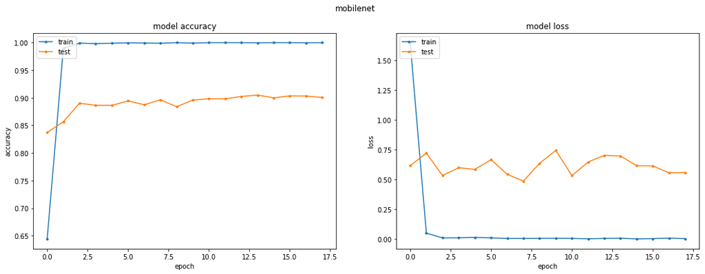

```
CPU times: user 9min 55s, sys: 38.3 s, total: 10min 33s
Wall time: 7min 24s
```

```python
%time mobilenet_finetuned = training_model('mobilenet',img_rows, img_cols,\
                                           color_type, preproc_function=preproc_mobilenet,\
                                           pretrained_model=mobilenet_model, data_augment=False)
```